# Data Analysis Project

# Introduction

We will be working with a dataset of auto claims filed by customers of an automobile insurance company located in the southwest and western regions of the United States.

Insurance companies depend on accurate pricing estimates to maintain profitability. Auto policies must be priced so that the insurance company makes a profit in the long run, given the costs of their customers’ payouts for accident repairs, total loss car replacements, medical fees, and legal fees.

The executives at this insurance company have noticed declining profitability over the last several years and have hired you as a data science consultant to evaluate their claims data and make recommendations on pricing, customer behavior, and car insurance policy adjustments.

The objective of this project is to perform exploratory data analysis on the claims_df dataset and produce an executive summary of your key insights and recommendations to the executive team at the insurance company.

Before you begin, take a moment to read through the following insurance company terms to familiarize yourself with the industry: [Auto Insurance Terms](https://www.iii.org/article/auto-insurance-jargon-buster)

## Auto Claims Data

The `claims_df` data frame is loaded below and consists of 6,249 auto claims submitted by customers of the insurance company. The rows in this data frame represent a single claim with all of the associated features that are displayed in the table below.

```r
library(tidyverse)
library(ggplot2)
library(dplyr)

claims_df <- readRDS(url('https://gmubusinessanalytics.netlify.app/data/claims_df.rds'))
```

### Raw Data

```r
claims_df
```

```
# A tibble: 6,249 × 20
   customer_id customer_state highest_education employment_status gender income
   <chr>       <fct>          <fct>             <fct>             <fct>   <dbl>
 1 AA11235     Nevada         Bachelor          Medical Leave     Female  11167
 2 AA16582     Washington     Bachelor          Medical Leave     Male    14072
 3 AA34092     California     Associate         Employed          Male    33635
 4 AA56476     Arizona        High School       Employed          Female  74454
 5 AA69265     Nevada         Bachelor          Employed          Female  60817
 6 AA71604     Arizona        Master            Employed          Female  87560
 7 AA93585     California     Associate         Employed          Male    97024
 8 AB21519     California     Associate         Employed          Female  93272
 9 AB23825     California     Associate         Employed          Male    21509
10 AB26022     Oregon         High School       Retired           Male    26487
# ℹ 6,239 more rows
# ℹ 14 more variables: residence_type <fct>, marital_status <fct>,
#   sales_channel <fct>, coverage <fct>, policy <fct>, vehicle_class <fct>,
#   vehicle_size <fct>, monthly_premium <dbl>, months_policy_active <dbl>,
#   months_since_last_claim <dbl>, current_claim_amount <dbl>,
#   total_claims <dbl>, total_claims_amount <dbl>,
#   customer_lifetime_value <dbl>
```

# Exploratory Data Analysis

Analyze the dataset:

```r
print("Unique in customer state")
```

```
[1] "Unique in customer state"
```

```r
unique(claims_df$customer_state)
```

```
[1] Nevada     Washington California Arizona    Oregon
Levels: Washington Oregon California Nevada Arizona
```

```r
print("Unique in highest_education")
```

```
[1] "Unique in highest_education"
```

```r
unique(claims_df$highest_education)
```

```
[1] Bachelor    Associate   High School Master      Doctoral
Levels: High School Associate Bachelor Master Doctoral
```

```r
print("Unique in employment_status")
```

```
[1] "Unique in employment_status"
```

```r
unique(claims_df$employment_status)
```

```
[1] Medical Leave Employed      Retired       Disabled
Levels: Employed Medical Leave Disabled Retired
```

```r
print("Unique in gender")
```

```
[1] "Unique in gender"
```

```r
unique(claims_df$gender)
```

```
[1] Female Male
Levels: Female Male
```

```r
print("range in income")
```

```
[1] "range in income"
```

```r
min(claims_df$income)
```

```
[1] 10037
```

```r
max(claims_df$income)
```

```
[1] 99981
```

```r
mean(claims_df$income)
```

```
[1] 49599.94
```

```r
median(claims_df$income)
```

```
[1] 46503
```

```r
print("Unique in residence_type")
```

```
[1] "Unique in residence_type"
```

```r
unique(claims_df$residence_type)
```

```
[1] Suburban Urban    Rural
Levels: Urban Suburban Rural
```

```r
print("Unique in marital_status")
```

```
[1] "Unique in marital_status"
```

```r
unique(claims_df$marital_status)
```

```
[1] Married  Divorced Single
Levels: Single Married Divorced
```

```r
print("Unique in sales_channel")
```

```
[1] "Unique in sales_channel"
```

```r
unique(claims_df$sales_channel)
```

```
[1] Branch      Agent       Web         Call Center
Levels: Agent Branch Call Center Web
```

```r
print("Unique in sales_channel")
```

```
[1] "Unique in sales_channel"
```

```r
unique(claims_df$sales_channel)
```

```
[1] Branch      Agent       Web         Call Center
Levels: Agent Branch Call Center Web
```

```r
print("Unique in coverage")
```

```
[1] "Unique in coverage"
```

```r
unique(claims_df$coverage)
```

```
[1] Basic    Extended Premium
Levels: Basic Extended Premium
```

```r
print("Unique in policy")
```

```
[1] "Unique in policy"
```

```r
unique(claims_df$policy)
```

```
[1] Personal  Corporate Special
Levels: Personal Corporate Special
```

```r
print("Unique in vehicle_class")
```

```
[1] "Unique in vehicle_class"
```

```r
unique(claims_df$vehicle_class)
```

```
[1] Two-Door Car  Four-Door Car Luxury SUV    SUV           Sports Car
[6] Luxury Car
Levels: Two-Door Car Four-Door Car Sports Car SUV Luxury Car Luxury SUV
```

```r
print("Unique in vehicle_size")
```

```
[1] "Unique in vehicle_size"
```

```r
unique(claims_df$vehicle_size)
```

```
[1] Midsize Small   Large
Levels: Small Midsize Large
```

```r
print("range in monthly_premium")
```

```
[1] "range in monthly_premium"
```

```r
min(claims_df$monthly_premium)
```

```
[1] 61
```

```r
max(claims_df$monthly_premium)
```

```
[1] 297
```

```r
mean(claims_df$monthly_premium)
```

```
[1] 93.80781
```

```r
median(claims_df$monthly_premium)
```

```
[1] 83
```

```r
print("range in months_policy_active")
```

```
[1] "range in months_policy_active"
```

```r
min(claims_df$months_policy_active)
```

```
[1] 12
```

```r
max(claims_df$months_policy_active)
```

```
[1] 71
```

```r
mean(claims_df$months_policy_active)
```

```
[1] 39.02864
```

```r
median(claims_df$months_policy_active)
```

```
[1] 38
```

```r
print("range in months_since_last_claim")
```

```
[1] "range in months_since_last_claim"
```

```r
min(claims_df$months_since_last_claim)
```

```
[1] 0
```

```r
max(claims_df$months_since_last_claim)
```

```
[1] 35
```

```r
mean(claims_df$months_since_last_claim)
```

```
[1] 14.97008
```

```r
median(claims_df$months_since_last_claim)
```

```
[1] 14
```

```r
print("range in current_claim_amount")
```

```
[1] "range in current_claim_amount"
```

```r
min(claims_df$current_claim_amount)
```

```
[1] 739
```

```r
max(claims_df$current_claim_amount)
```

```
[1] 3259
```

```r
mean(claims_df$current_claim_amount)
```

```
[1] 1625.444
```

```r
median(claims_df$current_claim_amount)
```

```
[1] 1628
```

```r
print("range in customer_lifetime_value")
```

```
[1] "range in customer_lifetime_value"
```

```r
min(claims_df$customer_lifetime_value)
```

```
[1] -4285
```

```r
max(claims_df$customer_lifetime_value)
```

```
[1] 16465
```

```r
mean(claims_df$customer_lifetime_value)
```

```
[1] 922.0635
```

```r
median(claims_df$customer_lifetime_value)
```

```
[1] 574
```

## Question 1

**Question**: Does gender and marital status affect the claim rate?

**Answer**: The gender does not affect the claim rate but married clients have significantly more claim rate.

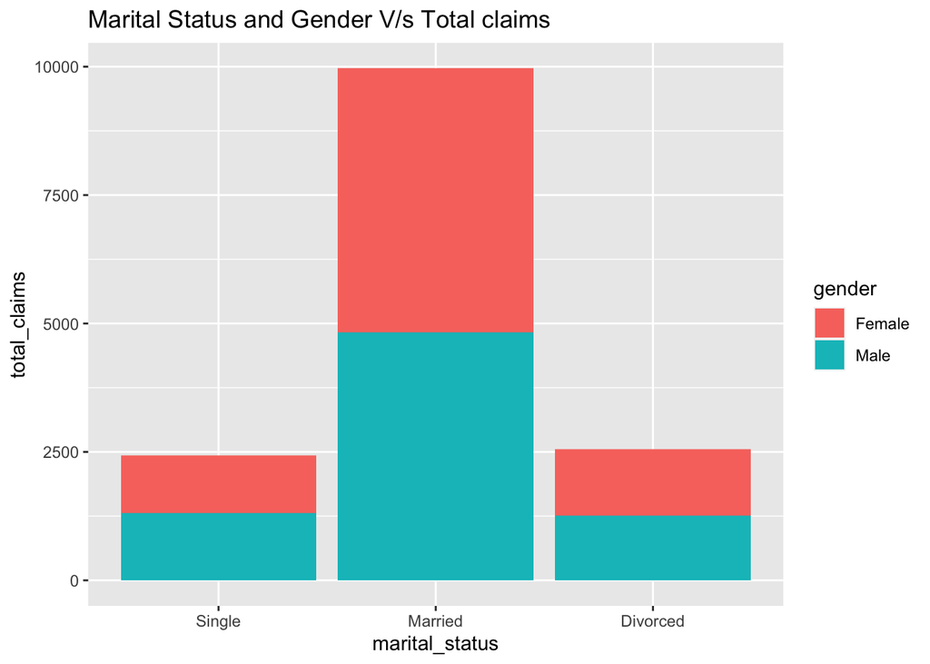

```r
ggplot(claims_df, aes(x=marital_status, y=total_claims, fill = gender))+
  geom_col()+
  ggtitle("Marital Status and Gender V/s Total claims")
```

## Question 2

**Question**:Does any state has more number of claims?

**Answer**: California has significantly higher number of claims. It is followed by Oregon, Arizona, Nevada, and Washington.

```r
claims_with_state <- claims_df[c(2,18)]
claims_with_state_summarized <- claims_with_state %>%
                                  group_by(customer_state) %>%
                                  summarize(total_claims= sum(total_claims))
claims_with_state_summarized
```

```
# A tibble: 5 × 2
  customer_state total_claims
  <fct>                 <dbl>
1 Washington             1331
2 Oregon                 4203
3 California             5185
4 Nevada                 1433
5 Arizona                2794
```

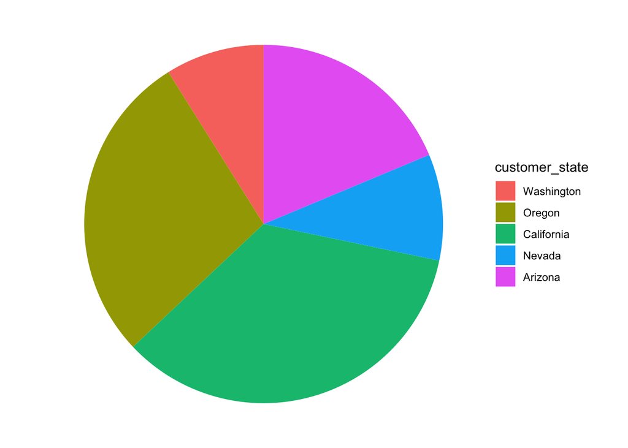

```r
ggplot(claims_with_state_summarized, aes(x="", y=total_claims, fill=customer_state)) +
  geom_bar(stat="identity", width=1) +
  coord_polar("y", start=0)+
  theme_void()
```

## Question 3

**Question**: Are there types of customers, based on their policy or demographics, that are highly profitable?

**Answer**: On calculating the total amount paid by the customer, we can find the percentage profit per customer. For this analysis I have only considered the customers that gave at least 50% profit to the company. Further, we will call these customers “Highly profitable customers.” There are 1,148 highly profitable customers. In all the states employed customers bring most profit. Also, personal policy type has most number of highly profitable customers. Extended coverage is also profitable.

```r
claims_df_high_profit <- claims_df %>%
                          filter(customer_lifetime_value>0) %>%
                          mutate(percentage_profit = ((monthly_premium * months_policy_active)-total_claims_amount)/(monthly_premium *     months_policy_active)*100) %>%
  arrange(percentage_profit) %>%
  filter(percentage_profit>50)

claims_df_high_profit
```

```
# A tibble: 1,148 × 21
   customer_id customer_state highest_education employment_status gender income
   <chr>       <fct>          <fct>             <fct>             <fct>   <dbl>
 1 QX31376     Oregon         Master            Employed          Female  70961
 2 VA30351     Oregon         High School       Employed          Female  74454
 3 JG31799     California     Bachelor          Disabled          Female  20305
 4 JU87932     Oregon         Bachelor          Employed          Female  30406
 5 DC79319     California     Bachelor          Employed          Female  29160
 6 TO20795     Washington     Doctoral          Employed          Male    37675
 7 GP22382     Oregon         Associate         Employed          Female  21685
 8 GN46207     Oregon         Master            Employed          Female  29462
 9 GV62858     California     Bachelor          Employed          Female  38692
10 QV86635     California     Bachelor          Employed          Male    28848
# ℹ 1,138 more rows
# ℹ 15 more variables: residence_type <fct>, marital_status <fct>,
#   sales_channel <fct>, coverage <fct>, policy <fct>, vehicle_class <fct>,
#   vehicle_size <fct>, monthly_premium <dbl>, months_policy_active <dbl>,
#   months_since_last_claim <dbl>, current_claim_amount <dbl>,
#   total_claims <dbl>, total_claims_amount <dbl>,
#   customer_lifetime_value <dbl>, percentage_profit <dbl>
```

```r
claims_df_high_profit%>% group_by(customer_state) %>%count(employment_status)
```

```
# A tibble: 20 × 3
# Groups:   customer_state [5]
   customer_state employment_status     n
   <fct>          <fct>             <int>
 1 Washington     Employed             71
 2 Washington     Medical Leave         7
 3 Washington     Disabled              7
 4 Washington     Retired               3
 5 Oregon         Employed            273
 6 Oregon         Medical Leave        23
 7 Oregon         Disabled             23
 8 Oregon         Retired              13
 9 California     Employed            314
10 California     Medical Leave        24
11 California     Disabled             34
12 California     Retired              19
13 Nevada         Employed             97
14 Nevada         Medical Leave        10
15 Nevada         Disabled              5
16 Nevada         Retired               5
17 Arizona        Employed            165
18 Arizona        Medical Leave        18
19 Arizona        Disabled             28
20 Arizona        Retired               9
```

```r
claims_df_high_profit%>% group_by(policy) %>%count(policy)
```

```
# A tibble: 3 × 2
# Groups:   policy [3]
  policy        n
  <fct>     <int>
1 Personal    854
2 Corporate   252
3 Special      42
```

```r
claims_df_high_profit%>% group_by(coverage) %>%count(coverage)
```

```
# A tibble: 3 × 2
# Groups:   coverage [3]
  coverage     n
  <fct>    <int>
1 Basic      351
2 Extended   518
3 Premium    279
```

## Question 4

**Question**: Is there any specific trend between education, residential type, and income of the highly profitable customers?

**Answer**: Most of the highly profitable customers have completed high schools, associate degree, and bachelor degree. Profitability is significantly low for master degree and doctoral. For income between 10k to 70k is the range where we get most of the profit. Most of the highly profitable customers are from suburban.

```
# A tibble: 25 × 3
# Groups:   customer_state [5]
   customer_state highest_education     n
   <fct>          <fct>             <int>
 1 Washington     High School          31
 2 Washington     Associate            19
 3 Washington     Bachelor             24
 4 Washington     Master               10
 5 Washington     Doctoral              4
 6 Oregon         High School          85
 7 Oregon         Associate           102
 8 Oregon         Bachelor             95
 9 Oregon         Master               38
10 Oregon         Doctoral             12
# ℹ 15 more rows
```

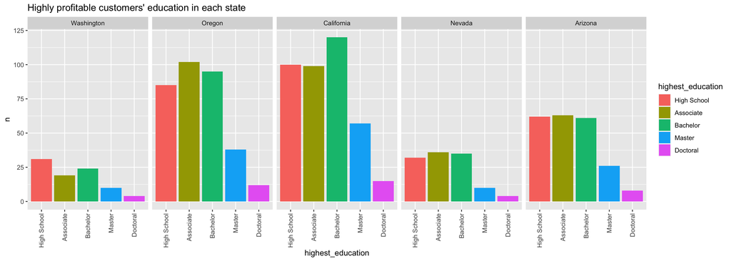

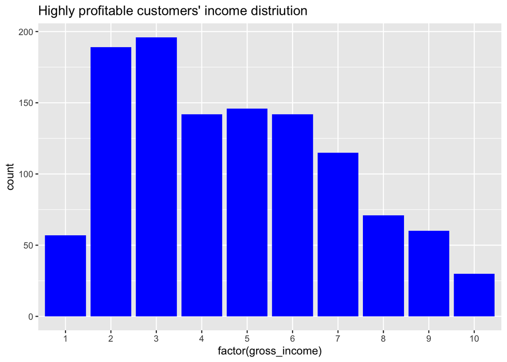

```r
claims_df_high_profit <- claims_df_high_profit%>%mutate(gross_income = round(income/10000))

ggplot(claims_df_high_profit, aes(x=factor(gross_income))) +
  geom_histogram(stat="count", fill="blue")+
  ggtitle("Highly profitable customers' income distriution ")
```

```r
claims_df_high_profit%>% group_by(residence_type) %>%count(residence_type)
```

```
# A tibble: 3 × 2
# Groups:   residence_type [3]
  residence_type     n
  <fct>          <int>
1 Urban            180
2 Suburban         756
3 Rural            212
```

## Question 5

**Question**: Are there “problem customers” which have a large number of claims?

**Answer**: Any customer with negative lifetime value (they received more money from the company than they paid to the insurance company), would be problem customer for the company. On filtering the customers with negative lifetime value and finding the median lifetime value for each number of claim made, we could see the total claim value paid to customers is increasing from 2 claims. 1005 customers have 3 total claims and 255 customers have 4 total claims. Moreover, there is drastic increase in median loss caused to the company as the total claims increases.

```r
problem_customers <- claims_df %>%
                      filter(customer_lifetime_value<0) %>%
                      group_by(total_claims) %>%
                      mutate(problem_customer_avg_customer_lifetime_value = median(customer_lifetime_value)) %>%
                      count(total_claims, problem_customer_avg_customer_lifetime_value)
problem_customers
```

```
# A tibble: 4 × 3
# Groups:   total_claims [4]
  total_claims problem_customer_avg_customer_lifetime_value     n
         <dbl>                                        <dbl> <int>
1            1                                        -468     64
2            2                                        -520.   886
3            3                                        -864   1005
4            4                                       -1594    255
```

```r
good_customers <- claims_df_high_profit%>%
                      group_by(total_claims) %>%
                      mutate(highly_profitable_avg_customer_lifetime_value = median(customer_lifetime_value)) %>%
                      count(total_claims, highly_profitable_avg_customer_lifetime_value)
good_customers
```

```
# A tibble: 4 × 3
# Groups:   total_claims [4]
  total_claims highly_profitable_avg_customer_lifetime_value     n
         <dbl>                                         <dbl> <int>
1            1                                         2042.    50
2            2                                         3365    935
3            3                                         4027    159
4            4                                         7703      4
```

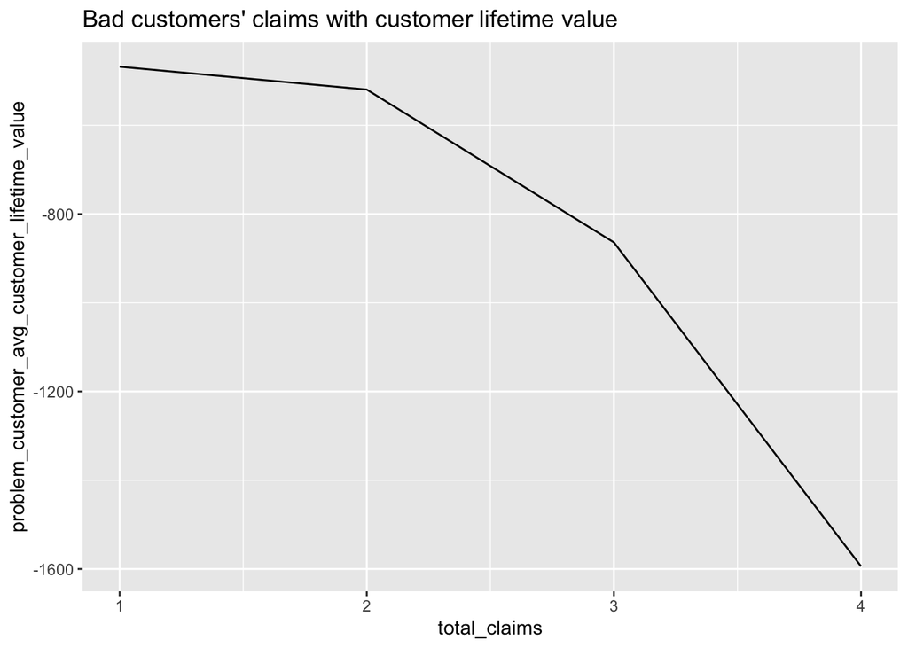

```r
ggplot(problem_customers, aes(x= total_claims, y = problem_customer_avg_customer_lifetime_value))+
  geom_line()+
  ggtitle("Bad customers' claims with customer lifetime value")
```

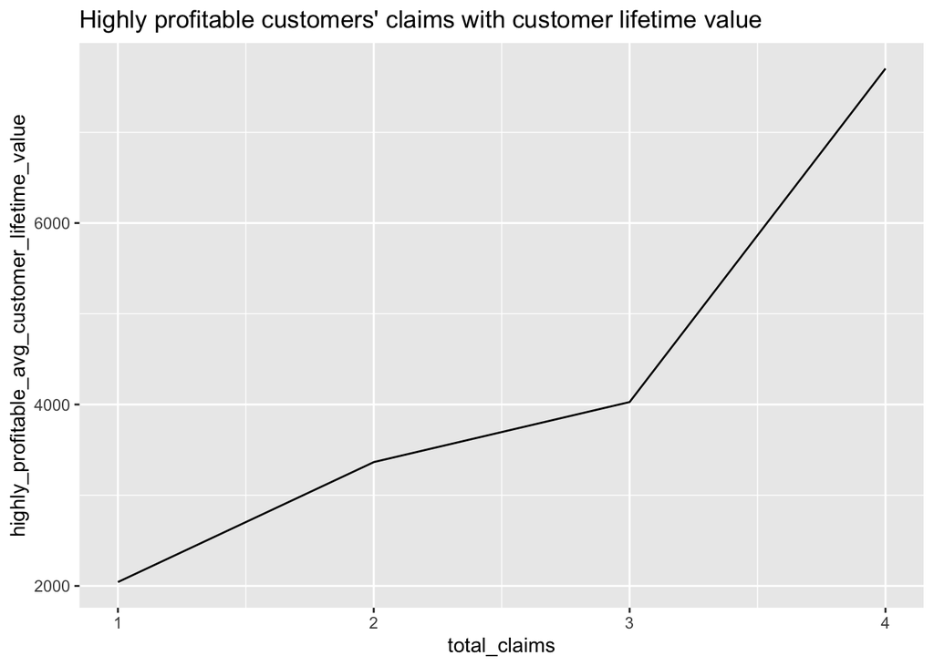

```r
ggplot(good_customers, aes(x= total_claims, y = highly_profitable_avg_customer_lifetime_value))+
  geom_line() +
  ggtitle("Highly profitable customers' claims with customer lifetime value")
```

## Question 6

**Question**: Is there any car category that is causing more loss? Also any sales channel has more loss making customers?

**Answer**: Midsize car category is causing more loss for all sales channel. Four-door vehicle class is causing more loss. Also, Agent and branch are the sales channel that has more loss making customers.

```
# A tibble: 12 × 3
# Groups:   vehicle_size [3]
   vehicle_size sales_channel     n
   <fct>        <fct>         <int>
 1 Small        Agent           168
 2 Small        Branch          118
 3 Small        Call Center     118
 4 Small        Web              56
 5 Midsize      Agent           591
 6 Midsize      Branch          444
 7 Midsize      Call Center     289
 8 Midsize      Web             225
 9 Large        Agent            79
10 Large        Branch           62
11 Large        Call Center      28
12 Large        Web              32
```

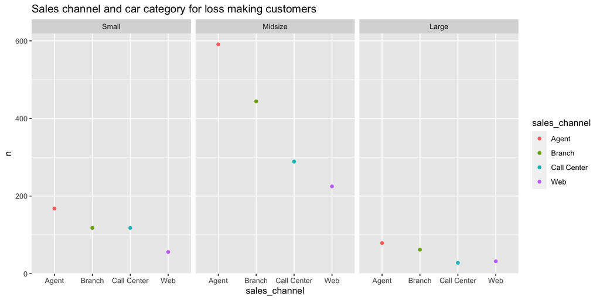

```r
loss_making_customers%>% group_by(vehicle_size) %>%count(vehicle_size)
```

```
# A tibble: 3 × 2
# Groups:   vehicle_size [3]
  vehicle_size     n
  <fct>        <int>
1 Small          460
2 Midsize       1549
3 Large          201
```

```r
loss_making_customers%>% group_by(vehicle_class) %>%count(vehicle_class)
```

```
# A tibble: 5 × 2
# Groups:   vehicle_class [5]
  vehicle_class     n
  <fct>         <int>
1 Two-Door Car    593
2 Four-Door Car  1387
3 Sports Car       37
4 SUV             192
5 Luxury SUV        1
```

## Question 7

**Question**: Which vehicle class has maximum high profitable customers? Any sales channel bringing more high profitable customers?

```
# A tibble: 12 × 3
# Groups:   vehicle_size [3]
   vehicle_size sales_channel     n
   <fct>        <fct>         <int>
 1 Small        Agent            94
 2 Small        Branch           61
 3 Small        Call Center      45
 4 Small        Web              28
 5 Midsize      Agent           324
 6 Midsize      Branch          226
 7 Midsize      Call Center     164
 8 Midsize      Web             101
 9 Large        Agent            41
10 Large        Branch           25
11 Large        Call Center      24
12 Large        Web              15
```

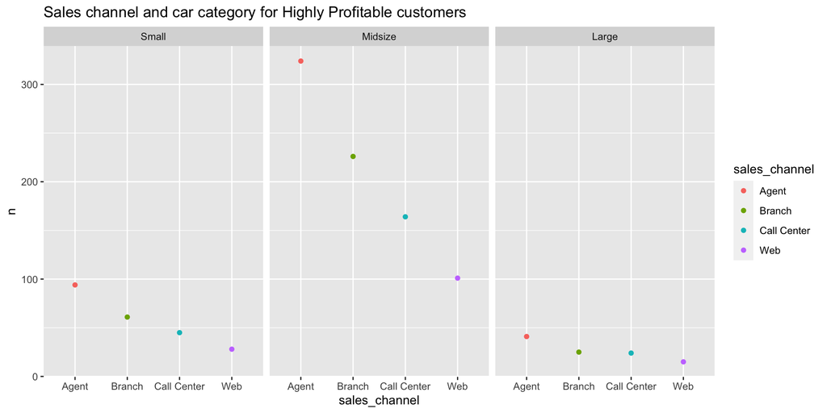

```r
claims_df_high_profit%>% group_by(vehicle_size) %>%count(vehicle_size)
```

```
# A tibble: 3 × 2
# Groups:   vehicle_size [3]
  vehicle_size     n
  <fct>        <int>
1 Small          228
2 Midsize        815
3 Large          105
```

```r
claims_df_high_profit%>% group_by(vehicle_class) %>%count(vehicle_class)
```

```
# A tibble: 6 × 2
# Groups:   vehicle_class [6]
  vehicle_class     n
  <fct>         <int>
1 Two-Door Car    119
2 Four-Door Car   269
3 Sports Car      120
4 SUV             428
5 Luxury Car       97
6 Luxury SUV      115
```

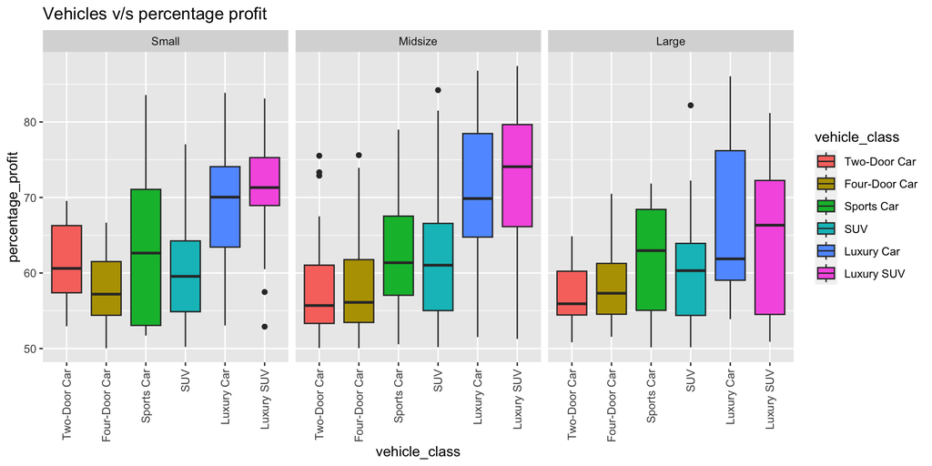

## Question 8

**Question**: Are highly profitable clients loyal customers of the company?

**Answer**: The highly profitable clients are old clients of the company. The highly profitable clients are minimum 16 months with the company and the oldest customer is for the 71 months. Hence, loyal custoers are highly profitable.

```r
claims_df_high_profit_months <- claims_df_high_profit%>% group_by(months_policy_active) %>%count(months_policy_active)
claims_df_high_profit_months
```

```
# A tibble: 53 × 2
# Groups:   months_policy_active [53]
   months_policy_active     n
                  <dbl> <int>
 1                   16     1
 2                   19     4
 3                   20     4
 4                   21     2
 5                   23     4
 6                   24     4
 7                   25     6
 8                   26     5
 9                   27     8
10                   28     9
# ℹ 43 more rows
```

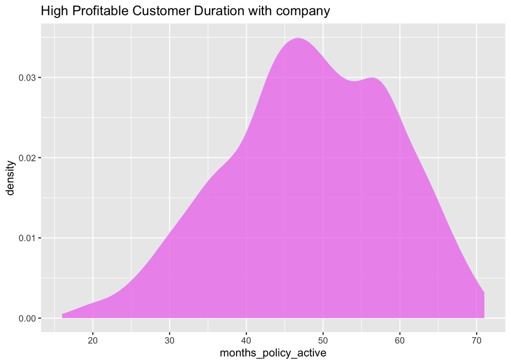

```r
ggplot(claims_df_high_profit, aes(x = months_policy_active))+
  geom_density(fill="violet", color="#e9ecef", alpha=0.8)+
  ggtitle("High Profitable Customer Duration with company")
```

## Question 9

**Question**: Are there types of customers, based on their policy or demographics, that are loss making(negative lifetime value) customers?

**Answer**: There are 2210 loss making customers. California has highest of such customers. In all the states employed customers bring most loss. Also, personal policy type has most number of loss making customers. Basic coverage is most among the loss making customers.

```r
loss_making_customers
```

```
# A tibble: 2,210 × 20
   customer_id customer_state highest_education employment_status gender income
   <chr>       <fct>          <fct>             <fct>             <fct>   <dbl>
 1 AA16582     Washington     Bachelor          Medical Leave     Male    14072
 2 AA71604     Arizona        Master            Employed          Female  87560
 3 AB21519     California     Associate         Employed          Female  93272
 4 AB69140     California     Master            Employed          Male    36007
 5 AB73565     California     Bachelor          Employed          Male    96748
 6 AC24378     Arizona        High School       Employed          Female  48552
 7 AC40767     Washington     Bachelor          Employed          Male    68041
 8 AC58002     California     Bachelor          Employed          Female  53907
 9 AC79024     Nevada         Bachelor          Employed          Male    23241
10 AD89594     California     Associate         Employed          Male    28651
# ℹ 2,200 more rows
# ℹ 14 more variables: residence_type <fct>, marital_status <fct>,
#   sales_channel <fct>, coverage <fct>, policy <fct>, vehicle_class <fct>,
#   vehicle_size <fct>, monthly_premium <dbl>, months_policy_active <dbl>,
#   months_since_last_claim <dbl>, current_claim_amount <dbl>,
#   total_claims <dbl>, total_claims_amount <dbl>,
#   customer_lifetime_value <dbl>
```

```r
loss_making_customers%>% group_by(customer_state) %>%count(employment_status)
```

```
# A tibble: 20 × 3
# Groups:   customer_state [5]
   customer_state employment_status     n
   <fct>          <fct>             <int>
 1 Washington     Employed            170
 2 Washington     Medical Leave        10
 3 Washington     Disabled             13
 4 Washington     Retired               6
 5 Oregon         Employed            521
 6 Oregon         Medical Leave        37
 7 Oregon         Disabled             33
 8 Oregon         Retired              19
 9 California     Employed            673
10 California     Medical Leave        45
11 California     Disabled             38
12 California     Retired              37
13 Nevada         Employed            175
14 Nevada         Medical Leave        13
15 Nevada         Disabled             17
16 Nevada         Retired               8
17 Arizona        Employed            338
18 Arizona        Medical Leave        25
19 Arizona        Disabled             19
20 Arizona        Retired              13
```

```r
loss_making_customers%>% group_by(policy) %>%count(policy)
```

```
# A tibble: 3 × 2
# Groups:   policy [3]
  policy        n
  <fct>     <int>
1 Personal   1665
2 Corporate   448
3 Special      97
```

```r
loss_making_customers%>% group_by(coverage) %>%count(coverage)
```

```
# A tibble: 3 × 2
# Groups:   coverage [3]
  coverage     n
  <fct>    <int>
1 Basic     1796
2 Extended   352
3 Premium     62
```

## Question 10

**Question**: Is there any specific trend between education, residential type, and income of the “problem customers”?

**Answer**: Most of the “problem customers” have completed high schools, associate degree, and bachelor degree. Loss is significantly low for master degree and doctoral. For income between 10k to 40k is the range where we get maximum of the loss, but this continuous till 90k. Most of the “problem customers” are from suburban.

```
# A tibble: 25 × 3
# Groups:   customer_state [5]
   customer_state highest_education     n
   <fct>          <fct>             <int>
 1 Washington     High School          55
 2 Washington     Associate            54
 3 Washington     Bachelor             69
 4 Washington     Master               16
 5 Washington     Doctoral              5
 6 Oregon         High School         163
 7 Oregon         Associate           185
 8 Oregon         Bachelor            187
 9 Oregon         Master               49
10 Oregon         Doctoral             26
# ℹ 15 more rows
```

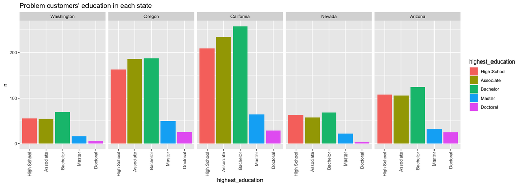

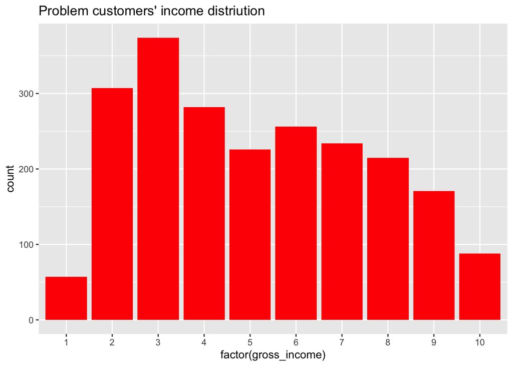

```r
loss_making_customers <- loss_making_customers%>%mutate(gross_income = round(income/10000))

ggplot(loss_making_customers, aes(x=factor(gross_income))) +
  geom_histogram(stat="count",fill="red")+
  ggtitle("Problem customers' income distriution ")
```

```r
loss_making_customers%>% group_by(residence_type) %>%count(residence_type)
```

```
# A tibble: 3 × 2
# Groups:   residence_type [3]
  residence_type     n
  <fct>          <int>
1 Urban            632
2 Suburban        1224
3 Rural            354
```

## Question 11

**Question**: Are “problem customers” clients new customers of the company?

**Answer**: The “problem customers” are mostly new clients of the company. The “problem customers” are median 30 months with the company and the oldest customer is for the 69 months and newest 12 months. Hence, “problem customers” are new customers.

```r
loss_making_customers_months <- loss_making_customers%>% group_by(months_policy_active) %>%count(months_policy_active) %>% arrange(months_policy_active)
loss_making_customers_months
```

```
# A tibble: 56 × 2
# Groups:   months_policy_active [56]
   months_policy_active     n
                  <dbl> <int>
 1                   12     5
 2                   13    15
 3                   14    28
 4                   15    27
 5                   16    41
 6                   17    50
 7                   18    48
 8                   19    61
 9                   20    74
10                   21    70
# ℹ 46 more rows
```

```r
loss_making_customers%>%  summarize(median = median(months_policy_active))
```

```
# A tibble: 1 × 1
  median
   <dbl>
1     30
```

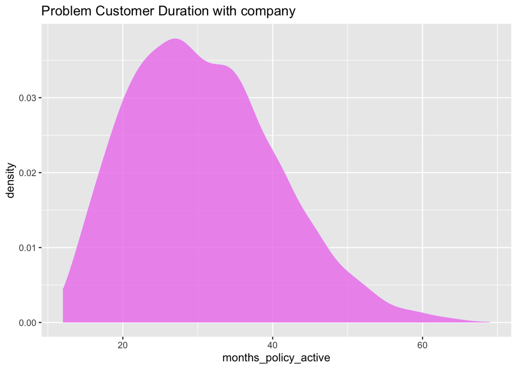

```r
ggplot(loss_making_customers, aes(x = months_policy_active))+
  geom_density(fill="violet", color="#e9ecef", alpha=0.8)+
  ggtitle("Problem Customer Duration with company")
```

# Summary of Results

## Executive Summary

The data belongs to the automobile insurance company. The main problem the company faces is a decrease in profit over the long run. To sustain any insurance company, they must be considered all factors to decide the premium of the policy. The goal of my analysis was to identify the factors and customers that are highly profitable to the insurance company and identify any pattern that can be seen in the problem customers. Apart from this, the analysis is done to recommend ways to improve the company’s profitability. I was trying to answer the questions that define the profitability and loss-making features of the customer. Since we are analyzing past data, preventive measures and improvements can be done to improve profitability.

The key findings from the analysis:

The goal is to increase the profit and decrease loss-making. Here are a few recommendations for this:

1. Increase the premium amount for married clients. The number of claims made by them is highest compared to single and divorced clients.
2. California state has the highest number of claims, followed by Oregon. It would be better if the company could increase the premium amount in these states.
3. The company has more “Personal” policy types with extended coverage with the most profit. If possible company could expand to accommodate new corporate clients. The most loss is seen with basic coverage. The company can review the rates for coverage so that clients find “extended” coverage more beneficial.
4. For all the states, master and doctoral clients have low drastic claim rates. The company can give more discounts to the clients with such high education, to attract new and preserve the old clients.
5. Suburban has the most profitable and loss-making customers. We can increase the premium amount to increase the profit, apart from this we can have discounts for rural and urban residents to attract new customers.
6. The company should monitor the claims made by the customers. If they have done more than 2 claims, the company should increase their premium amount.
7. Agents and branches are attracting both the most loss-making customers and profitable customers. The company should create some training programs to improve the quality of agents and branch employees so that they can access new clients and give them a premium amount that is beneficial for the company.
8. Loyal customers are highly profitable. It would be better if the company look into keeping the old clients first. To keep the clients for longer, the company could provide discounts to clients as they remain the client.